An Introduction to oTree Programming and Management of experiment in oTree Matteo Ploner (UNITN)

# Computerized experiments

## Advantages of computerized experiments

- Computerized experiments present several advantages over paper&pencil experiments
  - Live interaction
  - Dynamic interfaces
  - Codified data
  - Wide audience
    - Web-based experiments
- Specialized softwares are available
  - z-Tree [@fischbacher2007z] is the de-facto standard for lab experiments
    - Runs locally on Win OS
    - See [my online lecture notes](http://matteoploner.eco.unitn.it/zTreeCourse/index.html) if interested
  - oTree [@chen2016otree] is an emerging software
    - Platform-independent, web-based
- Here, we focus on oTree

## About oTree

- [oTree](http://www.otree.org/) is a framework based on [Python](https://www.python.org/) to run controlled experiments
  - Games
    - e.g., Public Goods Games (PGG)
  - Individual decision making
    - e.g., Risk elicitation tasks
  - Surveys and tests
    - e.g., Raven test
- Support by the community
  - [Forum](https://groups.google.com/forum/#!forum/otree)
  - Code developed by others
    - e.g. @holzmeister2017otree
    - A list of apps can be found [here](https://ckgk.de/otree.html)
- oTree is open-source,
  - Licensed under an adaptation of the MIT license.
    - Cite it in the paper when you use it

## Code

- Programming language of oTree is **Python**
  - Popular object-oriented programming language
  - Developed in early 90’s by [Guido Van Rossum](https://en.wikipedia.org/wiki/Guido_van_Rossum)
- OTree’s user interface is based on **HTML5**
  - Supported by modern browser and rich in functionalities
- OTree is based on **Django** web application framework
  - OTree applications are web applications
- All the components of oTree are free and open-source

## Functioning

- The basic setup consists in
  1. An **app (experiment)** written within oTree
  2. A **server** computer
  - Cloud server, local PC …
  3. Subjects’ **devices** with a browser
  - PC, Laptop, Tablet, Mobile Phone …
- oTree creates a session on the server and generates links for all participants
- Participants click on the links and are sent to a personal page
  - They submit their answers, which are collected by the server
  - The experimenter can check the progress on the server

[interactive chart not shown]

# oTree app

## Conceptual overview

| Session |  |  |  |  |  |
| --- | --- | --- | --- | --- | --- |
| Subsession |  |  |  | Subsession |  |
| Page | Page | Page | Page | Page | Page |

- **Sessions**
  - Participants take part in a series of tasks
- **Subsessions**
  - Sections of a session
    - EXAMPLE: a PGG is subsession 1 and a questionnaire is subsession 2
    - Repetitions of the same task are performed over distinct subsessions (periods)
- **Page**
  - Sections of a subsession
    - EXAMPLE: the PGG is made of 4 pages (instructions, …) and the questionnaire of 2 pages
- **Groups**
  - Each subsession can be divided into groups of players
    - Groups can be shuffled between subsessions

## Object hierarchy

- oTree’s entities are organized with the following hyerarchy

[interactive chart not shown]

- A session is a series of subsessions
  - A subsession contains multiple groups
    - A group contains multiple players
      - Each player proceeds through multiple pages
- ⚠ player and participant have different meanings
  - A Player is a section of a Participant
    - Similar to Subsession and Session
      - e.g., a participant can be player X in a subsession and player Y in another subsession

## What is self?

- In our journey we will often encounter `self`
  - It is the *class* a method *belongs* to!
- As an example, in *models.py* we will find

```python
class Player(BasePlayer):
    def set_payoff(self):
        self.payoff=-99
```

- The `self` here is Player
  - The method `set_payoff` defines the payoff for the player

```python
class Group(BaseGroup):
    payoff = models.CurrencyField()
    def set_payoff(self):
        self.payoff = -99
```

- The `self` here is Group
  - The method `set_payoff` defines the payoff for the group

## Using self to access information in other objects

- The diagram shows the properties you can access with `self`
- If you are in a method in class *Player*, you have access to the property `payoff` with `self.payoff`

```python
class Player(BasePlayer):
  def set_payoff(self):
      self.payoff=-99
```

- If you are in a method in class *Page*, you need to “navigate” to the to the property `payoff` with `self.player.payoff`

```python
class PayoffPage(BasePlayer):
  def vars_for_template(self):
      return{'payoff':self.player.payoff}
```

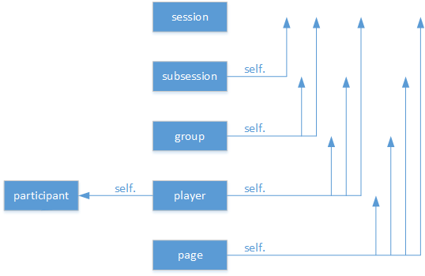

## Illustrative example of self in *models.py*

- models.py is the file that controls the database of the app
  - Subsession
    - Group
      - Player

```python
class Subsession(BaseSubsession):
    def example(self):

        # current subsession object
        self

        # parent objects
        self.session

        # child objects
        self.get_groups()
        self.get_players()

        # accessing previous Subsession objects
        self.in_previous_rounds()
        self.in_all_rounds()

class Group(BaseGroup):
    def example(self):

        # current group object
        self

        # parent objects
        self.session
        self.subsession

        # child objects
        self.get_players()

class Player(BasePlayer):

    def example(self):

        # current player object
        self

        # method you defined on the current object
        self.my_custom_method()

        # parent objects
        self.session
        self.subsession
        self.group
        self.participant

        self.session.config

        # accessing previous player objects
        self.in_previous_rounds()

        # equivalent to self.in_previous_rounds() + [self]
        self.in_all_rounds()
```

# Your first app

## Create an app

- To create an app named “*my_first_app*” move to the oTree folder

```bash
cd oTree
```

- and create the app

```bash
otree startapp my_first_app
```

- Move to the folder *my_first_app*
  - You will find the following files
    - **models.py**
    - **pages.py**
    - tests.py
  - And a subfolder
    - **templates/my_first_app**
      - **MyPage.html**, **Results.html**

## models.py

- Here you define the structure of your data
  - 3 data models
    - Subsession
    - Group
    - Player
      - These are Python classes (see below)
  - A model is basically a **database**
    - Specify columns and their nature
      - Integers, strings, …

```python
from otree.api import (
    models,
    widgets,
    BaseConstants,
    BaseSubsession,
    BaseGroup,
    BasePlayer,
    Currency as c,
    currency_range,
)

author = "Me"

doc = """
This is my first app
"""

class Constants(BaseConstants):
    name_in_url = 'my_first_app'
    players_per_group = None
    num_rounds = 1

class Subsession(BaseSubsession):
    pass

class Group(BaseGroup):
    pass

class Player(BasePlayer):
    pass
```

## templates

- These are the pages that are displayed to participants
  - **html files** that contain informations and *forms*
    - *forms* are used to collect data
  - A default MyPage.html is created
    - {% formfields %} will display the forms of the page
      - see *pages.py*
    - {% next_button %} will display a button to continue
- The HTML can contain “fancy” stuff
  - Javascript
  - Bootstrap framework
  - …

```xml
{% extends "global/Page.html" %}
{% load otree static %}

{% block title %}
    Page title
{% endblock %}

{% block content %}

    {% formfields %}

    {% next_button %}

{% endblock %}
```

## pages.py

- Pages that the participants see are defined in *pages.py*
  - Logic for how to display the HTML templates
    - when, how, and what to display
- *page_sequence* gives the order of pages
  - if there are multiple rounds the sequence is repeated

```python
from otree.api import Currency as c, currency_range
from ._builtin import Page, WaitPage
from .models import Constants


class MyPage(Page):
    pass


class ResultsWaitPage(WaitPage):
    def after_all_players_arrive(self):
        pass


class Results(Page):
    pass


page_sequence = [MyPage, ResultsWaitPage, Results]
```

# Implement a simple survey

## Steps to implement the survey

- We implement a simple survey to collect the age of course participants
1. Develop the oTree code
   - models.py
   - pages.py
   - templates
2. Test our code locally
3. Transfer our code to a server (running oTree)
4. Send links to participants (you)
5. Fill in the survey
6. Collect outcomes and analyze them

## Develop the oTree code: models.py

```python
from otree.api import (
    models,
    widgets,
    BaseConstants,
    BaseSubsession,
    BaseGroup,
    BasePlayer,
    Currency as c,
    currency_range,
)


author = 'Your name here'

doc = """
Collect participants' age
"""


class Constants(BaseConstants):
    name_in_url = 'my_first_survey'
    players_per_group = None
    num_rounds = 1


class Subsession(BaseSubsession):
    pass


class Group(BaseGroup):
    pass


class Player(BasePlayer):
    age = models.IntegerField(choices=range(18, 99, 1))
```

## Develop the oTree code: pages.py

```python
from otree.api import Currency as c, currency_range
from ._builtin import Page, WaitPage
from .models import Constants


class CollectAge(Page):
    form_model = 'player'
    form_fields = ['age']

class Results(Page):
    def vars_for_template(self):
        return{
            'your_age':self.player.age
        }


page_sequence = [CollectAge, Results]
```

- In page `CollectAge` we insert a form for class *player*
  - The field is `age`
    - Must be the same name we used in models.py
      - `age` and not, as an example, `Age`
- In page `Results` we give a feedback
  - `your_age` will be printed on the screen
- `page_sequence` defines the sequence of your pages
  - All your pages are a class that must be defined here

## Develop the oTree code: templates

- Templates are in the subfolder `templates/my_first_survey`
- **CollectAge**

```python
{% extends "global/Page.html" %}
{% load otree static %}

  {% block title %}
      Insert your age here
  {% endblock %}

{% block content %}

{% formfield player.age %}

{% next_button %}

{{ form.age.errors }}

{% endblock %}
```

- `{% formfield player.age %}` is where the information is input
  - Variable `age` in the class player
- Aesthetics elements
  - Title
  - Body
  - Next button

## Develop the oTree code: templates (ii)

- Templates are in the subfolder `templates/my_first_survey`
- **Results**

```python
{% extends "global/Page.html" %}
{% load otree static %}

{% block title %}
    Your age
{% endblock %}

{% block content %}

Your age is {{ your_age }}. Thank you for answering!

    {% next_button %}
{% endblock %}
```

- `{{ your_age }}` is passed by `vars_for_template` in pages.py
  - The right name must be put within `{{ }}` brackets

## Test our code locally

- Move to the folder in which your oTree is installed
  - Usually `cd ~/oTree`
  - Add your new app to the `settings.py file

```python
SESSION_CONFIGS = [
    dict(
        name='my_first_survey',
        display_name='my_first_survey',
        num_demo_participants=4,
        app_sequence=['my_first_survey'],
    )
]
```

- In `app_sequence` the exact name of the apps should be given
- Give command

```bash
otree devserver
```

## Test our code locally (ii)

- Open a browser and insert `http://localhost:8000/`

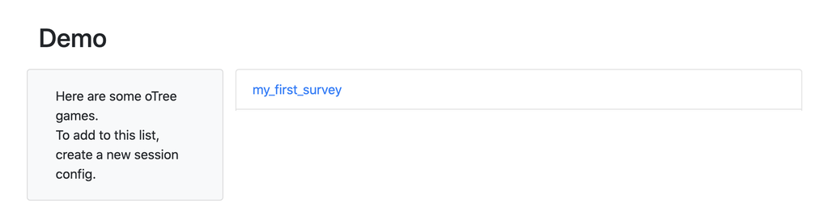

- Click on the name of your app

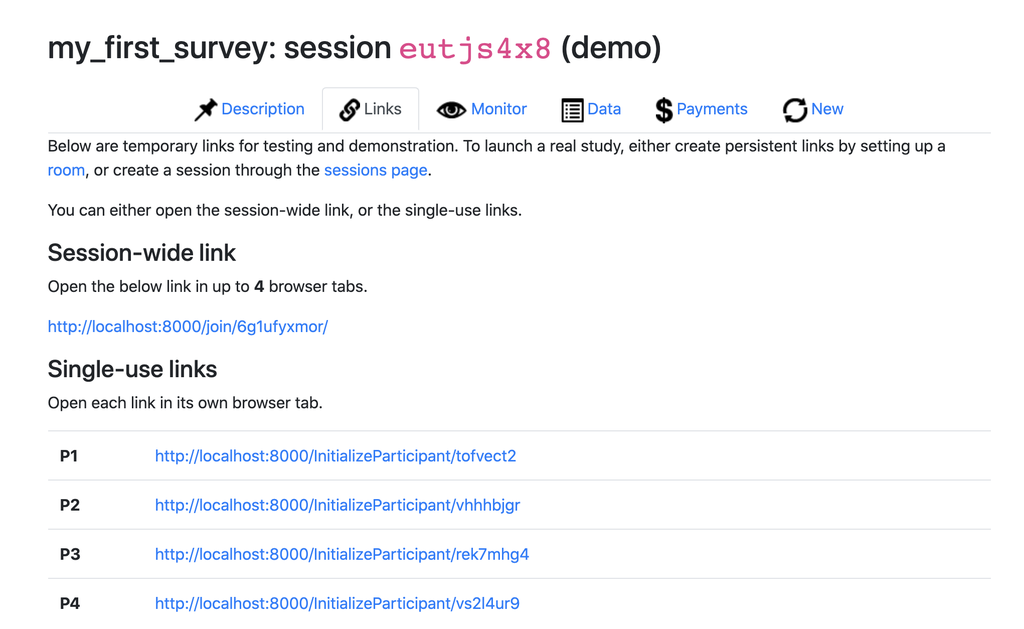

- Click on the session-wide link and try it

# Python

## Basics

- A very short introduction to Python
  - Based on [Learn X in Y minutes, where X=Python](https://learnxinyminutes.com/docs/python/) Attribution-ShareAlike 3.0 Unported (CC BY-SA 3.0)
  - and on @ascher1999learning

```python
#####################################################
# Numbers and logical operators
####################################################

# Math is what you would expect
1 + 1   # => 2
8 - 1   # => 7
10 * 2  # => 20
35 / 5  # => 7.0

# Enforce precedence with parentheses
1 + 3 * 2  # => 7
(1 + 3) * 2  # => 8


# Boolean Operators
## Note "and" and "or" are case-sensitive
True and False  # => False
False or True   # => True

## True and False are actually 1 and 0 but with different keywords
True + True # => 2
True * 8    # => 8
False - 5   # => -5

# Comparisons

## Equality is ==
1 == 1  # => True
2 == 1  # => False

## Inequality is !=
1 != 1  # => False
2 != 1  # => True

## More comparisons
1 < 10  # => True
1 > 10  # => False
2 <= 2  # => True
2 >= 2  # => True
```

## Basics: Strings and variables

- Strings are an ordered collection of *characters*

```python
# Strings are created with " or '

"This is a string."

'This is also a string.'

# Strings can be added too! But try not to do this.
"Hello " + "world!"  # => "Hello world!"

# You can also format using f-strings or formatted string literals (in Python 3.6+)
name = "Reiko"
f"{name} is {len(name)} characters long." # => "Reiko is 5 characters long."

# Strings can be sliced and indexed

name[0] => "R"
name[-2]  => "k"


# There are no declarations, only assignments.
# Convention is to use lower_case_with_underscores
some_var = 5
some_var  # => 5
```

## Basics: Lists and tuples

- Lists are ordered collections of arbitrary items
  - Can contain *numbers, strings, and other lists*
  - Accessed by offset
    - As an example, all players in a group

```python
# empty list
li = []

# Prefilled list
other_li = [4, 5, 6]

# Add stuff to the end of a list with append
other_li.append(7)    # => li is now [4, 5, 6, 7]

# Remove from the end with pop
other_li.pop()        # => 7 li is now [4, 5, 6]

# Access a list like you would any array
other_li [0]   # => 4

# Look at the last element
other_li [-1]  # => 6

# You can look at ranges with slice syntax.
# The start index is included, the end index is not
# (It's a closed/open range for you mathy types.)
other_li [1:3]   # Return list from index 1 to 3 => [5, 6]

# Remove arbitrary elements from a list with "del"
del other_li[2]  # li is now [4, 5]

# Insert an element at a specific index
other_li.insert(1, 2)  # li is now [4, 2, 5] again

# Get the index of the first item found matching the argument
other_li.index(2)  # => 1

# Check for existence in a list with "in"
1 in other_li  # => False

# Examine the length with "len()"
len(other_li)  # => 3

# Tuples are like lists but are immutable.
tup = (1, 2, 3)
tup[0]      # => 1
```

## Basics: Dictionaries

- Useful way to collect and organize information
  - As an example, payoffs of players

```python
# Dictionaries store mappings from keys to values

empty_dict = {}

# Here is a prefilled dictionary
filled_dict = {"one": 1, "two": 2, "three": 3}

# Look up values with []
filled_dict["one"]  # => 1

# Get all keys as an iterable with "keys()". We need to wrap the call in list()
# to turn it into a list. Order of insertion is preserved (in Python >=3.7)

list(filled_dict.keys())  # => ["one", "two", "three"]


# Get all values as an iterable with "values()". Once again we need to wrap it
# in list() to get it out of the iterable.

list(filled_dict.values())  # => [1, 2, 3]

# Check for existence of keys in a dictionary with "in"
"one" in filled_dict  # => True
1 in filled_dict      # => False

# Adding to a dictionary
filled_dict.update({"four":4})  # => {"one": 1, "two": 2, "three": 3, "four": 4}
filled_dict["four"] = 4         # another way to add to dict

# Remove keys from a dictionary with del
del filled_dict["one"]  # Removes the key "one" from filled dict
```

## Basics: Dictionaries in oTree

- File *setting.py* in oTree controls the apps that are run
  - Apps are dictionaries contained in a list *SESSION_CONFIGS*
    - keys: name, display_name, num_demo_participants, app_sequence, …

```python
SESSION_CONFIGS = [
    dict(
        name='my_first_survey',
        display_name='my_first_survey',
        num_demo_participants=4,
        app_sequence=['my_first_survey'],
    ),
    dict(
        name='self',
        display_name='importance_of_self',
        num_demo_participants=4,
        app_sequence=['what_is_self'],
    )
]
```

```python
SESSION_CONFIGS[0].keys()
```

- dict_keys([‘name’, ‘display_name’, ‘num_demo_participants’, ‘app_sequence’])

```python
SESSION_CONFIGS[0].values()
```

- dict_values([‘my_first_survey’, ‘my_first_survey’, 4, [‘my_first_survey’]])

## Basics: Control Flow and Iteration

- Many times you need to iterate through variables
  - As an example, collect all choice sof participants in a group

```python
# Let's just make a variable
some_var = 5

# Here is an if statement. Indentation is significant in Python!
# Convention is to use four spaces, not tabs.
# This prints "some_var is smaller than 10"

# if conditions

if some_var > 10:
    print("some_var is totally bigger than 10.")
elif some_var < 10:    # This elif clause is optional.
    print("some_var is smaller than 10.")
else:                  # This is optional too.
    print("some_var is indeed 10.")

# loops

for i in range(4):
    print(i)
# =>0
# =>1
# =>2
# =>3

for animal in ["dog", "cat", "mouse"]:
    # You can use format() to interpolate formatted strings
    print("{} is a mammal".format(animal))
# =>dog is a mammal
# =>cat is a mammal
# =>mouse is a mammal

# We can use list comprehensions to loop or filter
numbers = [3, 4, 5, 6, 7]
[x for x in numbers if x > 5]   # => [6, 7]
```

- Indenting is important!

## Basics: Functions

- Functions are a device that groups a bunch of statements

```python
# Use "def" to create new functions
def add(x, y):
    print("x is {} and y is {}".format(x, y))
    return x + y  # Return values with a return statement

# Calling functions with parameters
add(5, 6)  # => prints out "x is 5 and y is 6" and returns 11
```

## Basics: Classes

- Classes are main **object-oriented-programming (OOP)** in Python
  - **Class objects** provide default behavior
    - The *class* statement creates a class object and assigns it a name
    - Assignments inside class statements make class attributes
    - Class attributes export object state and behavior
      - *def* statements inside class generate a *method*
  - **Instance objects** are generated from classes
    - Calling a class object makes a new *instance object*
    - Each instance object inherits class attributes and gets its own namespace
    - Assignments to *self* in methods make per-instance attributes
      - *self* refers to the instance being processed

## Classes: An Example

- Pokemon is a **class** with some properties
  - Height
  - Weight
  - Category
- Two **instances** of the class →

**Bulbasaur**:

- Height: 2’ 04";
- Weight: 15.2 lbs;
- Category: Seed

## Classes: An Example (ii)

```python
class Pokemon:
    nature = "Pokemon"# this property is shared by all instances
    def __init__(self, name, height, weight, category):
            # Assign the argument to the instance's name attribute
            self.name = name
            self.height = height
            self.weight = weight
            self.category = category
            self.comment=[]
    # to add a comment
    def add_comment(self, comment):
        self.comment.append(comment)
    # convert height and weight into metric
    def convert_metric(self):
        # conversion rates
        feet_conv_cm=30.5
        inch_conv_cm=2.54
        lbs_conv_kg=0.453592
        self.height_cm = int(self.height.split("'")[0])*feet_conv_cm+int(self.height.split("'")[1])*inch_conv_cm
        self.weight_kg = self.weight*lbs_conv_kg
        # print the result
        print("Height (cm): %f, Weight (Kg): %f" %(self.height_cm, self.weight_kg))
```

## Classes: An Example (iii)

```python
# Create two instances of the class
p_1 = Pokemon("Charmander","2' 5''", 18.7, "Lizard")
p_2 = Pokemon("Bulbasaur","2' 04''", 15.2, "Seed")

# Add a comment
p_1.add_comment("Its ability is Blaze")
p_2.add_comment("Its ability is Overgrow")

# Convert their measures in metric system
p_1.convert_metric()
p_2.convert_metric()

# Who is taller?
if p_1.height>p_2.height:
    print(p_1.name + " is taller")
elif p_1.height<p_2.height:
    print(p_2.name + " is taller")
else:
    print(p_2.name + " and" + p_1.name + "are equally taller")
```

# Appendix

## Assignment

- 1. Consider the *class Pokemon* we illustrated above
  - Print the name of p_1? Print the ability of p_1?
  - Create a new instance of the class
  - **Charizard**: Height: 5’ 07"; Weight: 199.5 lbs; Category: Flame
  - Check whether Charizard is taller than Bulbasaur
- 2. Extend our survey to collect gender
  - Hint: the variable in class Player could be implemented like this

  ```python
  sex =  models.CharField(widget=widgets.RadioSelectHorizontal(),choices=['Male', 'Female'])
  ```